# Final Project: Political Ideology and People’s Perception of Global Warming

$\\$

### Author: Qinrui Xiahou, School of Forestry & Environmental Studies

### Discussants: The data this study uses come from the Yale Program on Climate Change Communication ([YPCCC](https://osf.io/w36gn/)). I didn’t consult anyone when doing the analysis.

$\\$

## 1. Introduction

Studies on peer-reviewed journals show that 97% of scientists agree that humans are causing global warming over the past century ([NASA, 2019](https://climate.nasa.gov/scientific-consensus/)). However, the overwhelming consensus cannot be found in the general public in the U.S. In the context of political polarization, Democrats, Independents and Republicans seem to hold vastly different opinions on the topic of global warming. Does political ideology play an important role in their perceptions? What proportion of people care about global warming in each ideology group? These questions are relevant to both politicians and activists.

In this study, I analyze the relationship between political ideology and people’s perceptions of global warming from three aspects: the acceptance of the fact of global warming, the recognition of scientific consensus and the worries about global warming impacts. Data are from the database *[Climate Change in the American Mind (2008-2017)](https://osf.io/w36gn/)*, which is a biannual survey conducted by Yale Program on Climate Change Communication (YPCCC) & George Mason University Center for Climate Change Communication. This database has been widely used by researchers and journalists. [Gustafson et al. (2019)](https://climatecommunication.yale.edu/publications/a-growing-majority-of-americans-think-global-warming-is-happening-and-are-worried/) found that a growing of Americans are alarmed about global warming over the past five years. [Ballew et al.(2019)](https://www.tandfonline.com/doi/full/10.1080/00139157.2019.1589300) pointed out that there are generational differences of the perceptions of global warming within Democratic and Republican parties. And [Leiserowitz et al. (2016)](https://climatecommunication.yale.edu/wp-content/uploads/2016/05/2016_3_CCAM_Global-Warming-U.S.-Presidential-Election.pdf) looked into the 2016 presidential election and found that the supporters of Democratic candidates are much more likely to recognize climate change science. To my best knowledge, there is no prior studies that dug into the ideological divides and explained differences with statistical inference. This study aims to provide insights in this regard. (All the analysis is original to this course and has not been used in any other projects.)

$\\$

## 2. Descriptive Analysis

### 2.1 Data Wrangling

This study uses the dataset called *CCAM_SPSS_Data* from the *[Climate Change in the American Mind (2008-2017)](https://osf.io/w36gn/)* database. The original dataset includes 17 waves of nationally representative surveys, 54 variables and 20024 observations. For the sake of convenience and efficiency, wranglings are done to keep only relevant variables and valid answers. Most of the codes are hided but can be found **[here](https://github.com/QinruiXH/SDS230-Final-Project)** along with comments and results. Basically, I first investigated how the variables were coded in the dataset using the *str()* function. Then, I kept the most recent data and variables of interest with *dplyr* functions. As some of the questions had too many options, I categorized people into different groups and created new variables with clear labels.

```r
# First, we load the whole dataset.
library(haven)
CCAM_SPSS_Data <- read_sav("CCAM SPSS Data.sav")

# Get a sense of how the variables are coded.
# str(CCAM_SPSS_Data)

# Tailor the dataset to our research questions.
library(expss)
Climate_Opinions <- CCAM_SPSS_Data %>%
  # only keep the most recent data collected in 2017.
  filter(year==9) %>%
  # keep variables that we're interested in.
  select(ideology, happening, sci_consensus, worry) %>%
  # delete cases with N/A anwers (which are coded as -1 in the dataset).
  filter(ideology!=-1, happening!=-1, sci_consensus!=-1, worry!=-1) %>%
  drop_unused_labels() %>%
  # create a new variable categorizing people into "Liberal", "Moderate" and "Conservative" groups.
  mutate(ideology_group ={
    x <- rep("Liberal", length(ideology))
    x[ideology==3] <- "Moderate"
    x[ideology%in%c(4,5)] <- "Conservative"
    x
  }
) %>%
  apply_labels(ideology_group="Ideology Group") %>%
  # create a new variable categorizing people into "belief" and "no belief" groups.
  mutate(belief_group ={
    x <- rep("belief", length(happening))
    x[happening%in%c(1,2)] <- "no belief"
    x
  }
  ) %>%
# create a new variable categorizing people into "science" and "against science" groups.
  mutate(science_group ={
    x <- rep("science", length(sci_consensus))
    x[sci_consensus%in%c(1,2,3)] <- "against science"
    x
  }
  ) %>%
  # create a new variable categorizing people into "worried" and "not worried" groups.
  mutate(worry_group ={
    x <- rep("worried", length(worry))
    x[worry%in%c(1,2)] <- "not worried"
    x
  }
  )

# A summary of the dataset after wrangling.
summary(Climate_Opinions)
```

```
##     ideology       happening     sci_consensus       worry
##  Min.   :1.000   Min.   :1.000   Min.   :1.000   Min.   :1.000
##  1st Qu.:2.000   1st Qu.:2.000   1st Qu.:2.000   1st Qu.:2.000
##  Median :3.000   Median :3.000   Median :4.000   Median :3.000
##  Mean   :3.073   Mean   :2.566   Mean   :2.945   Mean   :2.617
##  3rd Qu.:4.000   3rd Qu.:3.000   3rd Qu.:4.000   3rd Qu.:3.000
##  Max.   :5.000   Max.   :3.000   Max.   :4.000   Max.   :4.000
##  ideology_group     belief_group       science_group      worry_group
##  Length:2541        Length:2541        Length:2541        Length:2541
##  Class1:labelled    Class :character   Class :character   Class :character
##  Class2:character   Mode  :character   Mode  :character   Mode  :character
##  Mode  :character
##
##
```

The dataset after wrangling, *Climate_Opinions* is summarized as follows. It has 8 variables and 2541 observations. *ideology_group* shows the political ideologies people group themselves into, namely “Conservative”, “Liberal” or “Moderate”. *belief_group*, *science_group* and *worry_group* indicate people’s acceptance of the fact of global warming, the recognition of scientific consensus and the worries about global warming impacts, respectively.

```r
# Get the dimensions of the dataset we use.
dim(Climate_Opinions)
```

```
## [1] 2541    8
```

```r
# A glimpse of the dataset after wrangling.
glimpse(Climate_Opinions)
```

```
## Observations: 2,541
## Variables: 8
## $ ideology       <dbl+lbl> 4, 2, 4, 4, 4, 2, 5, 3, 3, 4, 2, 4, 4, 3, 3, 2, ...
## $ happening      <dbl+lbl> 3, 3, 2, 3, 3, 3, 3, 3, 3, 2, 3, 1, 3, 3, 2, 3, ...
## $ sci_consensus  <dbl+lbl> 4, 4, 1, 4, 4, 4, 2, 2, 4, 1, 4, 2, 2, 4, 2, 4, ...
## $ worry          <dbl+lbl> 2, 3, 3, 2, 4, 4, 3, 4, 2, 3, 4, 3, 4, 4, 3, 3, ...
## $ ideology_group <labelled> "Conservative", "Liberal", "Conservative", "Con...
## $ belief_group   <chr> "belief", "belief", "no belief", "belief", "belief",...
## $ science_group  <chr> "science", "science", "against science", "science", ...
## $ worry_group    <chr> "not worried", "worried", "worried", "not worried", ...
```

$\\$

### 2.2 Data Visualization: Perceptions of Global Warming across Ideological Groups

In order to see whether there is a clear distinction of people’s perceptions across ideological groups, I made cross tables and stacked bar charts. Only the code for global warming beliefs is included here, and the rest are stored in **[Github](https://github.com/QinruiXH/SDS230-Final-Project)**. Generally, 70.6% of the U.S. public believe in the fact of global warming. The percentage is disproportionately high for liberals, among whom 94.2% think the global warming is true, while only 45.1% of the conservatives hold the same opinion.

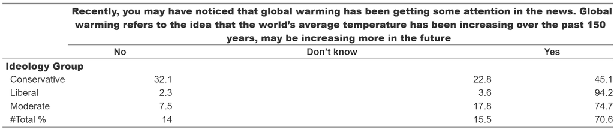

```r
# Summary table of people's ideology and global warming beliefs.
library(expss)
library(ggplot2)
#cro_rpct(Climate_Opinions$ideology_group, Climate_Opinions$happening,
         #total_statistic="u_rpct", total_label="Total %")
# (As complex tables cannot be knitted properly into pdf, I took a screenshot from the html
# file and added it as a picture.)
```

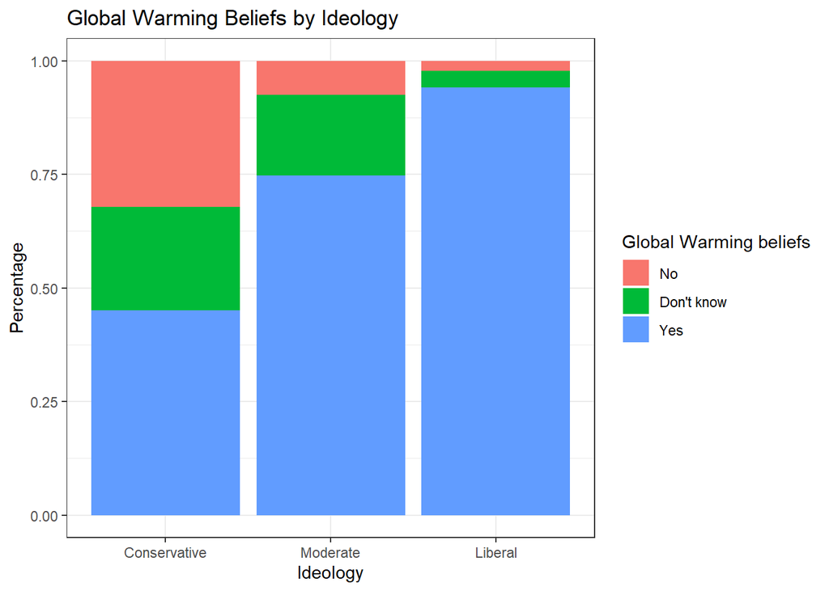

```r
# Visualization of people's ideology and global warming beliefs.
Climate_Opinions %>%
ggplot(aes(x = reorder(ideology_group,happening), y=as.numeric(as.logical(happening)),
           fill = as.factor(happening))) +
  geom_col(position = "fill") +
  scale_y_continuous() +
  xlab("Ideology") +
  ylab("Percentage") +
  ggtitle("Global Warming Beliefs by Ideology") +
  theme(plot.title = element_text(hjust = 0.5)) +
  scale_fill_discrete(name = "Global Warming beliefs") +
  theme_bw()
```

None of the groups have an accurate picture of the scientific consensus on global warming. On average, only about a half (53.8%) of Americans recognize the climate science. Most conservatives either don’t have enough knowledge or think there is a lot of disagreement among scientists. Half of the moderates recognize the consensus while the other half doubt it. 81.3% of liberals are aware of the consensus, but the percentage is lower than that of their belief in the fact of global warming.

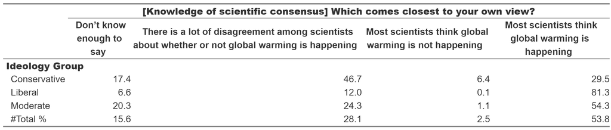

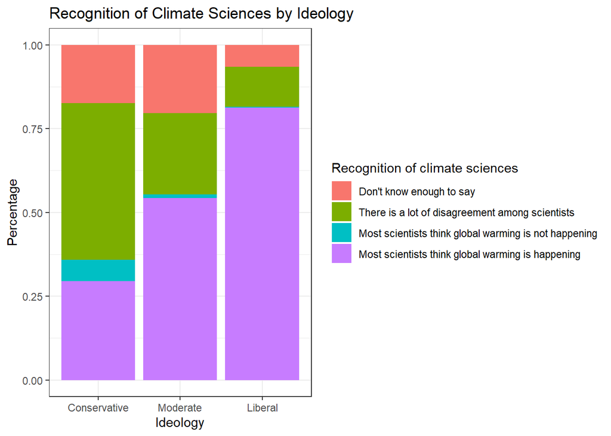

```r
# Summary table of people's ideology and recognition of climate sciences.
# cro_rpct(Climate_Opinions$ideology_group, Climate_Opinions$sci_consensus,
         # total_statistic="u_rpct", total_label="Total %")

# Visualization of people's ideology and recognition of climate sciences.
Climate_Opinions %>%
ggplot(aes(x = reorder(ideology_group,sci_consensus),
           y=as.numeric(as.logical(sci_consensus)),
           fill = as.factor(sci_consensus))) +
  geom_col(position = "fill") +
  scale_y_continuous() +
  scale_fill_discrete(name = "Recognition of climate sciences",
                      labels = c("Don't know enough to say",
                                 "There is a lot of disagreement among scientists",
                                 "Most scientists think global warming is not happening",
                                 "Most scientists think global warming is happening")) +
  xlab("Ideology") +
  ylab("Percentage") +
  ggtitle("Recognition of Climate Sciences by Ideology") +
  theme(plot.title = element_text(hjust = 0.5)) +
  theme_bw()
```

Although both the [U.S. Department of Defense](https://www.defense.gov/Explore/News/Article/Article/603440/) and the [UN Security Council](https://news.un.org/en/story/2019/01/1031322) regard global warming as a “threat multiplier”, the problem doesn’t seem to be a primary concern for ordinary American people. Merely 19.3% of Americans are very worried about global warming, and the percentage drops to 5.1% for conservatives. 34.7% of conservatives are not at all worried, in contrast to only 2.7% for liberals. Take all of three indicators into account, liberals generally care more about the global warming, the conservatives are mostly indifferent, and moderates lie somewhere in between.

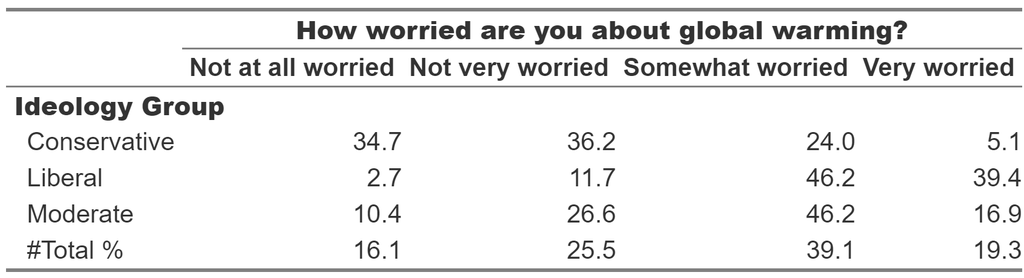

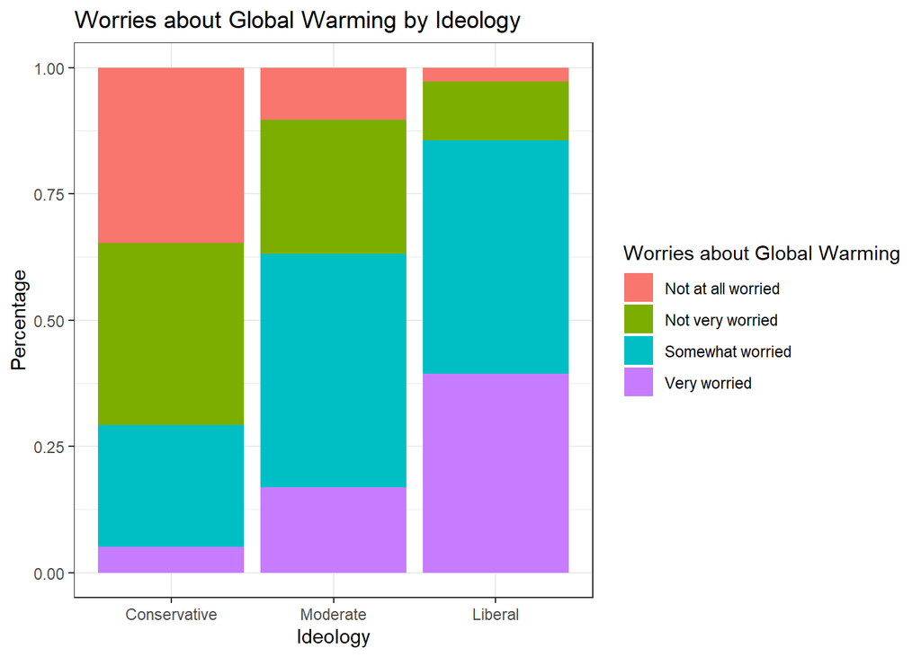

```r
# Summary table of people's ideology and worries about global warming.
# cro_rpct(Climate_Opinions$ideology_group, Climate_Opinions$worry,
         #total_statistic="u_rpct", total_label="Total %")

# Visualization of people's ideology and worries about global warming.
Climate_Opinions %>%
ggplot(aes(x = reorder(ideology_group,worry), y=as.numeric(as.logical(worry)),
           fill = as.factor(worry))) +
  geom_col(position = "fill") +
  scale_y_continuous() +
  xlab("Ideology") +
  ylab("Percentage")+
  ggtitle("Worries about Global Warming by Ideology") +
  theme(plot.title = element_text(hjust = 0.5)) +
  scale_fill_discrete(name = "Worries about Global Warming") +
  theme_bw()
```

$\\$

## 3. Statistical Analysis

### 3.1 Hypothesis Testing: Is there a Significant Difference of Perceptions of Global Warming between Ideological Groups?

From tables and plots, liberals, moderates and conservatives seem to regard global warming quite differently. Are these differences statistically significant? In other words, are people’s perceptions of global warming independent from their political ideologies? Here I use the hypothesis testing to explore the results.

Chi Square test is a statistical method used to determine whether two categorical variables have a significant correlation between them. It is a non-parametric tool that does not rely on the distribution of variables. [Assumptions in the chi square test](https://www.statisticssolutions.com/chi-square-test/) include: (1) Data are randomly sampled; (2) Samples are sufficiently large; (3) Observations are independent of each other. Considering the rigorous data collection methods and standardized procedures in this survey, it’s safe to assume that all the assumptions are met and continue our analysis with chi square test.

In terms of beliefs, the null hypothesis ($H_0$) is that whether people think global warming is happening is independent of their political ideology, and the alternative hypothesis ($H_A$) is that whether people think global warming is happening is correlated with their political ideologies. By convention, the significance level, $\alpha$ is set at 0.05.

As is shown in the following chunk, the observed statistic is 574.29, corresponding to a p-value of 2.2e-16. Obviously, the p-value is much smaller than the pre-set $\alpha$, and we can reject the null hypothesis and conclude that there is statistically significant evidence that people’s belief in climate change is correlated with political ideologies.

```r
tbl1=table(Climate_Opinions$happening,Climate_Opinions$ideology)
chisq.test(tbl1)
```

```
##
##  Pearson's Chi-squared test
##
## data:  tbl1
## X-squared = 574.29, df = 8, p-value < 2.2e-16
```

The same stories can be told with the recognition of climate science and worries about global warming. All of the three indicators are statistically different across ideological groups.

```r
tbl2=table(Climate_Opinions$sci_consensus,Climate_Opinions$ideology)
chisq.test(tbl2)
```

```
##
##  Pearson's Chi-squared test
##
## data:  tbl2
## X-squared = 535.13, df = 12, p-value < 2.2e-16
```

```r
tbl3=table(Climate_Opinions$worry,Climate_Opinions$ideology)
chisq.test(tbl3)
```

```
##
##  Pearson's Chi-squared test
##
## data:  tbl3
## X-squared = 770.69, df = 12, p-value < 2.2e-16
```

### 3.2 Confidence Interval: What can We Expect of People’s Perceptions of Global Warming in Each Ideological Group?

Now that we know people with different political ideologies hold statistically different perceptions of global warming, a following question is how we can expect the results for the whole population of U.S. citizens. Confidence intervals can serve this role well. Here I compute the confidence intervals for each of the three indicators with three methods we’ve covered in class, and discuss whether the results are similar to each other.

```r
# First, we calculate the proportion of people who believe that global warming is happening
# in each ideology group.
prop_hat <- NULL
for (i in c("Liberal","Conservative","Moderate")){
  Subset_belief <- filter(Climate_Opinions, ideology_group==i)
  prop_hat[i] <- summarize(Subset_belief,
                           prop_belief=mean(Subset_belief$belief_group=="belief")) %>%
  pull()
}
prop_hat
```

```
##      Liberal Conservative     Moderate
##    0.9415121    0.4509804    0.7470703
```

```r
# Then, we calculate confidence intervals for the proportion using three methods we have
# covered in class.
boot_CI_lower <- NULL
boot_CI_upper <- NULL
perc_CI_lower <- NULL
perc_CI_upper <- NULL
formula_CI_lower <- NULL
formula_CI_upper <- NULL
for (i in c("Liberal","Conservative","Moderate")) {
  boot_dist <- NULL
  Subset_belief <- filter(Climate_Opinions, ideology_group==i)
  for (j in 1:10000){
    boot_sample <- sample(Subset_belief$belief_group, replace=TRUE)
    boot_dist[j] <- prop.table(table(boot_sample))[1]
  }
  SE_boot <- sd(boot_dist)
  boot_CI_lower[i] <- prop_hat[i]+SE_boot*(-2)
  boot_CI_upper[i] <- prop_hat[i]+SE_boot*(2)
  perc_CI_lower[i] <- quantile(boot_dist,0.025)
  perc_CI_upper[i] <- quantile(boot_dist,0.975)
  SE_formula <- sqrt((prop_hat[i]*(1-prop_hat[i]))/length(prop_hat[i]))
  formula_CI_lower[i] <- prop_hat[i]+SE_formula*(-2)
  formula_CI_upper[i] <- prop_hat[i]+SE_formula*(2)
}
```

Confidence intervals for the belief in global warming

[output not shown]

Confidence intervals for the recognition of science consensus

```r
# First, we calculate the proportion of people who acknowledge the consensus in climate
# science in each ideology group.
prop_hat <- NULL
for (i in c("Liberal","Conservative","Moderate")){
  Subset_science <- filter(Climate_Opinions, ideology_group==i)
  prop_hat[i] <- summarize(Subset_science,
                           prop_science=mean(Subset_science$science_group=="science")) %>%
  pull()
}

# Then, we calculate confidence intervals for the proportion using three methods we have
# covered in class.
boot_CI_lower <- NULL
boot_CI_upper <- NULL
perc_CI_lower <- NULL
perc_CI_upper <- NULL
formula_CI_lower <- NULL
formula_CI_upper <- NULL
for (i in c("Liberal","Conservative","Moderate")) {
  boot_dist <- NULL
  Subset_science <- filter(Climate_Opinions, ideology_group==i)
  for (j in 1:10000){
    boot_sample <- sample(Subset_science$science_group, replace=TRUE)
    boot_dist[j] <- prop.table(table(boot_sample))[2]
  }
  SE_boot <- sd(boot_dist)
  boot_CI_lower[i] <- prop_hat[i]+SE_boot*(-2)
  boot_CI_upper[i] <- prop_hat[i]+SE_boot*(2)
  perc_CI_lower[i] <- quantile(boot_dist,0.025)
  perc_CI_upper[i] <- quantile(boot_dist,0.975)
  SE_formula <- sqrt((prop_hat[i]*(1-prop_hat[i]))/length(prop_hat[i]))
  formula_CI_lower[i] <- prop_hat[i]+SE_formula*(-2)
  formula_CI_upper[i] <- prop_hat[i]+SE_formula*(2)
}
```

|  | Bootstrap SE | Bootstrap percentile | Formula |
| --- | --- | --- | --- |
| Conservative | [0.2634482,0.3272380] | [0.2647059,0.3272059] | [-0.61705057,1.207737] |
| Moderate | [0.5118996,0.5740379] | [0.5117188,0.5732422] | [-0.45333178,1.539269] |
| Liberal | [0.7840120,0.8422362] | [0.7845934,0.8416548] | [0.03350037,1.592748] |

Confidence intervals for worrying about global warming

```r
# First, we calculate the proportion of people who are worried about global warming in
# each ideology group.
prop_hat <- NULL
for (i in c("Liberal","Conservative","Moderate")){
  Subset_worry <- filter(Climate_Opinions, ideology_group==i)
  prop_hat[i] <- summarize(Subset_worry,
                           prop_worried=mean(Subset_worry$worry_group=="worried")) %>%
  pull()
}


# Then, we calculate confidence intervals for the proportion using three methods we have
# covered in class.
boot_CI_lower <- NULL
boot_CI_upper <- NULL
perc_CI_lower <- NULL
perc_CI_upper <- NULL
formula_CI_lower <- NULL
formula_CI_upper <- NULL
for (i in c("Liberal","Conservative","Moderate")) {
  boot_dist <- NULL
  Subset_worry <- filter(Climate_Opinions, ideology_group==i)
  for (j in 1:10000){
    boot_sample <- sample(Subset_worry$worry_group, replace=TRUE)
    boot_dist[j] <- prop.table(table(boot_sample))[2]
  }
  SE_boot <- sd(boot_dist)
  boot_CI_lower[i] <- prop_hat[i]+SE_boot*(-2)
  boot_CI_upper[i] <- prop_hat[i]+SE_boot*(2)
  perc_CI_lower[i] <- quantile(boot_dist,0.025)
  perc_CI_upper[i] <- quantile(boot_dist,0.975)
  SE_formula <- sqrt((prop_hat[i]*(1-prop_hat[i]))/length(prop_hat[i]))
  formula_CI_lower[i] <- prop_hat[i]+SE_formula*(-2)
  formula_CI_upper[i] <- prop_hat[i]+SE_formula*(2)
}
```

|  | Bootstrap SE | Bootstrap percentile | Formula |
| --- | --- | --- | --- |
| Conservative | [0.2598309,0.3235024] | [0.2598039,0.3223039] | [-0.6173927,1.200726] |
| Moderate | [0.6005394,0.6611793] | [0.6005859,0.6611328] | [-0.3342848,1.596004] |
| Liberal | [0.8294731,0.8823672] | [0.8302425,0.8815977] | [0.1535787,1.558262] |

$\\$

## 4. Conclusion

In this study, I explored the relationship between political ideology and people’s perceptions of global warming. Both intuitional and statistical evidence suggest that the political polarization and ideological divides hold true for the global warming topic as well. Liberals are generally well aware of the problem, the scientific background, and potential risks to their life. In contrast, global warming plays a negligible role to conservatives, most of whom are unconvinced of the overwhelming scientific consensus. Moderates lie somewhere in between, but 75% of them recognize this problem and 60% are worried about its future impacts.

The results are relevant to both politicians and activists. Considering the 2020 presidential election, it can be reasonably expected that almost all of the Democratic candidates would support efforts to combat climate change, while their Republican counterparts won’t do so. For environmental activists, their target audience should be focused on Republican states and citizens, and providing science-based information could be one of their priorities.

Due to the time limit, this study is far from perfect. Future work can be done with respect to spatial and time-series analysis. Are people’s opinions on global warming affected by their perceived social consensus? Which of the ideological groups have changed their opinions most dramatically over the last decade? How important is the topic of global warming as a voting issue? All of the above questions are worth investigating in the future.

$\\$

## 5. Reflection

I’m very grateful to do this project all by myself. It’s not only a precious opportunity to apply the methods and theories we’ve covered in class, but more importantly, it greatly enhanced my confidence in programming, including choosing appropriate tests, adjusting parameters, debugging and formatting. What I can learn from a course is limited, while such experience enables me to understand the logic behind research and to become comfortable exploring new concepts in the future.

$\\$